# Risk Factor Analysis

## Outcome Variable

**Outcome Variable:** haz

## Predictor Variables

**Intervention Variable:** earlybf

**Adjustment Set:**

- arm
- sex
- W_mage
- meducyrs
- feducyrs
- hhwealth_quart
- hfoodsec
- W_mhtcm
- W_mwtkg
- W_mbmi
- vagbrth
- W_gagebrth
- W_birthwt
- W_birthlen
- W_nrooms
- W_nchldlt5
- brthmon
- W_parity
- impfloor
- impsan
- safeh20
- delta_W_mage
- delta_meducyrs
- delta_feducyrs
- delta_hhwealth_quart
- delta_hfoodsec
- delta_W_mhtcm
- delta_W_mwtkg
- delta_W_mbmi
- delta_vagbrth
- delta_W_gagebrth
- delta_W_birthwt
- delta_W_birthlen
- delta_W_nrooms
- delta_W_nchldlt5
- delta_brthmon
- delta_W_parity
- delta_impfloor
- delta_impsan
- delta_safeh20

## Stratifying Variables

The analysis was stratified on these variable(s):

- agecat
- studyid
- country

## Data Summary

| agecat | studyid | country | earlybf | n_cell | n | outcome_variable |
| --- | --- | --- | --- | --- | --- | --- |
| Birth | EE | PAKISTAN | 1 | 44 | 229 | haz |
| Birth | EE | PAKISTAN | 0 | 185 | 229 | haz |
| Birth | GMS-Nepal | NEPAL | 1 | 180 | 632 | haz |
| Birth | GMS-Nepal | NEPAL | 0 | 452 | 632 | haz |
| Birth | JiVitA-3 | BANGLADESH | 1 | 236 | 22370 | haz |
| Birth | JiVitA-3 | BANGLADESH | 0 | 22134 | 22370 | haz |
| Birth | JiVitA-4 | BANGLADESH | 1 | 1912 | 2823 | haz |
| Birth | JiVitA-4 | BANGLADESH | 0 | 911 | 2823 | haz |
| Birth | MAL-ED | BANGLADESH | 1 | 147 | 230 | haz |
| Birth | MAL-ED | BANGLADESH | 0 | 83 | 230 | haz |
| Birth | MAL-ED | BRAZIL | 1 | 28 | 65 | haz |
| Birth | MAL-ED | BRAZIL | 0 | 37 | 65 | haz |
| Birth | MAL-ED | INDIA | 1 | 32 | 46 | haz |
| Birth | MAL-ED | INDIA | 0 | 14 | 46 | haz |
| Birth | MAL-ED | NEPAL | 1 | 14 | 27 | haz |
| Birth | MAL-ED | NEPAL | 0 | 13 | 27 | haz |
| Birth | MAL-ED | PERU | 1 | 175 | 233 | haz |
| Birth | MAL-ED | PERU | 0 | 58 | 233 | haz |
| Birth | MAL-ED | SOUTH AFRICA | 1 | 69 | 111 | haz |
| Birth | MAL-ED | SOUTH AFRICA | 0 | 42 | 111 | haz |
| Birth | MAL-ED | TANZANIA, UNITED REPUBLIC OF | 1 | 111 | 125 | haz |
| Birth | MAL-ED | TANZANIA, UNITED REPUBLIC OF | 0 | 14 | 125 | haz |
| Birth | NIH-Crypto | BANGLADESH | 1 | 634 | 732 | haz |
| Birth | NIH-Crypto | BANGLADESH | 0 | 98 | 732 | haz |
| Birth | SAS-CompFeed | INDIA | 1 | 86 | 1207 | haz |
| Birth | SAS-CompFeed | INDIA | 0 | 1121 | 1207 | haz |
| Birth | ZVITAMBO | ZIMBABWE | 1 | 6556 | 12354 | haz |
| Birth | ZVITAMBO | ZIMBABWE | 0 | 5798 | 12354 | haz |
| 6 months | EE | PAKISTAN | 1 | 68 | 362 | haz |
| 6 months | EE | PAKISTAN | 0 | 294 | 362 | haz |

[output cut: 52 more lines]

The following strata were considered:

- agecat: 24 months, studyid: EE, country: PAKISTAN
- agecat: 24 months, studyid: GMS-Nepal, country: NEPAL
- agecat: 24 months, studyid: JiVitA-3, country: BANGLADESH
- agecat: 24 months, studyid: JiVitA-4, country: BANGLADESH
- agecat: 24 months, studyid: MAL-ED, country: BANGLADESH
- agecat: 24 months, studyid: MAL-ED, country: BRAZIL
- agecat: 24 months, studyid: MAL-ED, country: INDIA
- agecat: 24 months, studyid: MAL-ED, country: NEPAL
- agecat: 24 months, studyid: MAL-ED, country: PERU
- agecat: 24 months, studyid: MAL-ED, country: SOUTH AFRICA
- agecat: 24 months, studyid: MAL-ED, country: TANZANIA, UNITED REPUBLIC OF
- agecat: 24 months, studyid: NIH-Crypto, country: BANGLADESH
- agecat: 24 months, studyid: ZVITAMBO, country: ZIMBABWE
- agecat: 6 months, studyid: EE, country: PAKISTAN
- agecat: 6 months, studyid: GMS-Nepal, country: NEPAL
- agecat: 6 months, studyid: JiVitA-3, country: BANGLADESH
- agecat: 6 months, studyid: JiVitA-4, country: BANGLADESH
- agecat: 6 months, studyid: MAL-ED, country: BANGLADESH
- agecat: 6 months, studyid: MAL-ED, country: BRAZIL
- agecat: 6 months, studyid: MAL-ED, country: INDIA
- agecat: 6 months, studyid: MAL-ED, country: NEPAL
- agecat: 6 months, studyid: MAL-ED, country: PERU
- agecat: 6 months, studyid: MAL-ED, country: SOUTH AFRICA
- agecat: 6 months, studyid: MAL-ED, country: TANZANIA, UNITED REPUBLIC OF
- agecat: 6 months, studyid: NIH-Crypto, country: BANGLADESH
- agecat: 6 months, studyid: SAS-CompFeed, country: INDIA
- agecat: 6 months, studyid: ZVITAMBO, country: ZIMBABWE
- agecat: Birth, studyid: EE, country: PAKISTAN
- agecat: Birth, studyid: GMS-Nepal, country: NEPAL
- agecat: Birth, studyid: JiVitA-3, country: BANGLADESH
- agecat: Birth, studyid: JiVitA-4, country: BANGLADESH
- agecat: Birth, studyid: MAL-ED, country: BANGLADESH
- agecat: Birth, studyid: MAL-ED, country: BRAZIL
- agecat: Birth, studyid: MAL-ED, country: INDIA
- agecat: Birth, studyid: MAL-ED, country: NEPAL
- agecat: Birth, studyid: MAL-ED, country: PERU
- agecat: Birth, studyid: MAL-ED, country: SOUTH AFRICA
- agecat: Birth, studyid: MAL-ED, country: TANZANIA, UNITED REPUBLIC OF
- agecat: Birth, studyid: NIH-Crypto, country: BANGLADESH
- agecat: Birth, studyid: SAS-CompFeed, country: INDIA
- agecat: Birth, studyid: ZVITAMBO, country: ZIMBABWE

### Dropped Strata

Some strata were dropped due to rare outcomes:

- agecat: 24 months, studyid: JiVitA-3, country: BANGLADESH

## Methods Detail

We’re interested in the causal parameters $E[Y_a]$ for all values of $a \in \mathcal{A}$. These parameters represent the mean outcome if, possibly contrary to fact, we intervened to set all units to have $A=a$. Under the randomization and positivity assumptions, these are identified by the statistical parameters $\psi_a=E_W[E_{Y|A,W}(Y|A=a,W)]$. In addition, we’re interested in the mean of $Y$, $E[Y]$ under no intervention (the observed mean). We will estimate these parameters by using SuperLearner to fit the relevant likelihood factors – $E_{Y|A,W}(Y|A=a,W)$ and $p(A=a|W)$, and then updating our likelihood fit using a joint TMLE.

For unadjusted analyses ($W=\{\}$), initial likelihoods were estimated using Lrnr_glm to estimate the simple $E(Y|A)$ and Lrnr_mean to estimate $p(A)$. For adjusted analyses, a small library containing Lrnr_glmnet, Lrnr_xgboost, and Lrnr_mean was used.

Having estimated these parameters, we will then use the delta method to estimate relative risks and attributable risks relative to a prespecified baseline level of $A$.

# Results Detail

## Results Plots

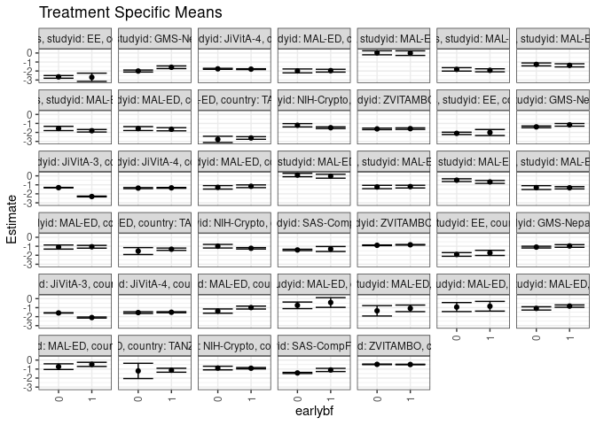

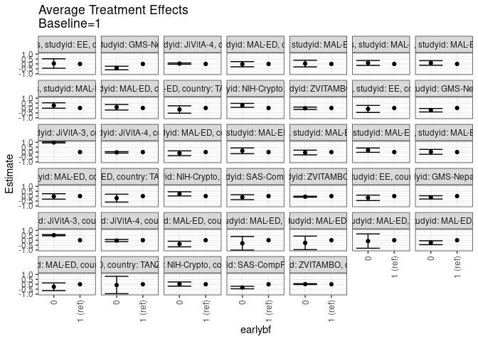

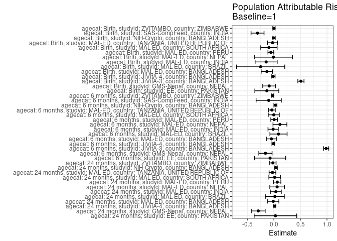

## Results Table

### Parameter: TSM

| agecat | studyid | country | intervention_level | baseline_level | estimate | ci_lower | ci_upper |
| --- | --- | --- | --- | --- | --- | --- | --- |
| Birth | EE | PAKISTAN | 1 | NA | -1.7388595 | -2.0263260 | -1.4513930 |
| Birth | EE | PAKISTAN | 0 | NA | -1.9112538 | -2.1131731 | -1.7093345 |
| Birth | GMS-Nepal | NEPAL | 1 | NA | -0.9690796 | -1.1142853 | -0.8238739 |
| Birth | GMS-Nepal | NEPAL | 0 | NA | -1.0945649 | -1.1915051 | -0.9976246 |
| Birth | JiVitA-3 | BANGLADESH | 1 | NA | -2.0991352 | -2.1577269 | -2.0405436 |
| Birth | JiVitA-3 | BANGLADESH | 0 | NA | -1.5872740 | -1.6068263 | -1.5677217 |
| Birth | JiVitA-4 | BANGLADESH | 1 | NA | -1.5103602 | -1.5679320 | -1.4527883 |
| Birth | JiVitA-4 | BANGLADESH | 0 | NA | -1.5482460 | -1.6416153 | -1.4548768 |
| Birth | MAL-ED | BANGLADESH | 1 | NA | -0.9895977 | -1.1494499 | -0.8297455 |
| Birth | MAL-ED | BANGLADESH | 0 | NA | -1.3794470 | -1.6160254 | -1.1428687 |
| Birth | MAL-ED | BRAZIL | 1 | NA | -0.4271220 | -0.9663420 | 0.1120979 |
| Birth | MAL-ED | BRAZIL | 0 | NA | -0.7412517 | -1.1061050 | -0.3763985 |
| Birth | MAL-ED | INDIA | 1 | NA | -1.0764520 | -1.4432314 | -0.7096727 |
| Birth | MAL-ED | INDIA | 0 | NA | -1.3494915 | -1.9258797 | -0.7731033 |
| Birth | MAL-ED | NEPAL | 1 | NA | -0.8445680 | -1.3860664 | -0.3030696 |
| Birth | MAL-ED | NEPAL | 0 | NA | -0.9338059 | -1.4364540 | -0.4311578 |
| Birth | MAL-ED | PERU | 1 | NA | -0.8259402 | -0.9549449 | -0.6969355 |
| Birth | MAL-ED | PERU | 0 | NA | -1.0832910 | -1.2649270 | -0.9016551 |
| Birth | MAL-ED | SOUTH AFRICA | 1 | NA | -0.4775233 | -0.7072325 | -0.2478142 |
| Birth | MAL-ED | SOUTH AFRICA | 0 | NA | -0.7319227 | -1.0459991 | -0.4178463 |
| Birth | MAL-ED | TANZANIA, UNITED REPUBLIC OF | 1 | NA | -1.1300529 | -1.3485383 | -0.9115674 |
| Birth | MAL-ED | TANZANIA, UNITED REPUBLIC OF | 0 | NA | -1.2056696 | -2.0532667 | -0.3580725 |
| Birth | NIH-Crypto | BANGLADESH | 1 | NA | -0.9070107 | -0.9821375 | -0.8318839 |
| Birth | NIH-Crypto | BANGLADESH | 0 | NA | -0.8870225 | -1.0888569 | -0.6851882 |
| Birth | SAS-CompFeed | INDIA | 1 | NA | -1.0994066 | -1.2772210 | -0.9215922 |
| Birth | SAS-CompFeed | INDIA | 0 | NA | -1.4308867 | -1.4933116 | -1.3684618 |
| Birth | ZVITAMBO | ZIMBABWE | 1 | NA | -0.4912916 | -0.5218734 | -0.4607097 |
| Birth | ZVITAMBO | ZIMBABWE | 0 | NA | -0.4757134 | -0.5071473 | -0.4442795 |
| 6 months | EE | PAKISTAN | 1 | NA | -2.0120953 | -2.3464641 | -1.6777265 |
| 6 months | EE | PAKISTAN | 0 | NA | -2.1049088 | -2.2338539 | -1.9759637 |
| 6 months | GMS-Nepal | NEPAL | 1 | NA | -1.1588004 | -1.3069483 | -1.0106525 |
| 6 months | GMS-Nepal | NEPAL | 0 | NA | -1.3829640 | -1.4801283 | -1.2857997 |
| 6 months | JiVitA-3 | BANGLADESH | 1 | NA | -2.2974269 | -2.3423038 | -2.2525499 |
| 6 months | JiVitA-3 | BANGLADESH | 0 | NA | -1.3111312 | -1.3347395 | -1.2875229 |
| 6 months | JiVitA-4 | BANGLADESH | 1 | NA | -1.3341720 | -1.3802471 | -1.2880968 |
| 6 months | JiVitA-4 | BANGLADESH | 0 | NA | -1.3628802 | -1.4217668 | -1.3039936 |
| 6 months | MAL-ED | BANGLADESH | 1 | NA | -1.1586431 | -1.3086234 | -1.0086629 |
| 6 months | MAL-ED | BANGLADESH | 0 | NA | -1.2792702 | -1.4698590 | -1.0886814 |
| 6 months | MAL-ED | BRAZIL | 1 | NA | -0.0396665 | -0.2614712 | 0.1821383 |
| 6 months | MAL-ED | BRAZIL | 0 | NA | 0.0874594 | -0.1036259 | 0.2785446 |
| 6 months | MAL-ED | INDIA | 1 | NA | -1.1976682 | -1.3499939 | -1.0453425 |
| 6 months | MAL-ED | INDIA | 0 | NA | -1.2419624 | -1.4296770 | -1.0542478 |
| 6 months | MAL-ED | NEPAL | 1 | NA | -0.6756636 | -0.8371023 | -0.5142249 |
| 6 months | MAL-ED | NEPAL | 0 | NA | -0.4815206 | -0.6343917 | -0.3286495 |
| 6 months | MAL-ED | PERU | 1 | NA | -1.3284757 | -1.4553023 | -1.2016491 |
| 6 months | MAL-ED | PERU | 0 | NA | -1.3048300 | -1.5175620 | -1.0920979 |
| 6 months | MAL-ED | SOUTH AFRICA | 1 | NA | -1.0579889 | -1.2119181 | -0.9040596 |
| 6 months | MAL-ED | SOUTH AFRICA | 0 | NA | -1.0900336 | -1.3178135 | -0.8622536 |
| 6 months | MAL-ED | TANZANIA, UNITED REPUBLIC OF | 1 | NA | -1.3305089 | -1.4592669 | -1.2017510 |
| 6 months | MAL-ED | TANZANIA, UNITED REPUBLIC OF | 0 | NA | -1.5349485 | -1.9199161 | -1.1499810 |
| 6 months | NIH-Crypto | BANGLADESH | 1 | NA | -1.2279398 | -1.3044886 | -1.1513910 |
| 6 months | NIH-Crypto | BANGLADESH | 0 | NA | -0.9959464 | -1.1962613 | -0.7956315 |
| 6 months | SAS-CompFeed | INDIA | 1 | NA | -1.3046030 | -1.5804232 | -1.0287828 |
| 6 months | SAS-CompFeed | INDIA | 0 | NA | -1.4110959 | -1.4864420 | -1.3357497 |
| 6 months | ZVITAMBO | ZIMBABWE | 1 | NA | -0.8376521 | -0.8731013 | -0.8022028 |
| 6 months | ZVITAMBO | ZIMBABWE | 0 | NA | -0.8921987 | -0.9307008 | -0.8536967 |
| 24 months | EE | PAKISTAN | 1 | NA | -2.6972724 | -3.1547900 | -2.2397548 |
| 24 months | EE | PAKISTAN | 0 | NA | -2.6518056 | -2.8010289 | -2.5025824 |
| 24 months | GMS-Nepal | NEPAL | 1 | NA | -1.5848334 | -1.7327819 | -1.4368849 |
| 24 months | GMS-Nepal | NEPAL | 0 | NA | -2.0022363 | -2.1121954 | -1.8922771 |
| 24 months | JiVitA-4 | BANGLADESH | 1 | NA | -1.7931547 | -1.8373363 | -1.7489730 |
| 24 months | JiVitA-4 | BANGLADESH | 0 | NA | -1.7596784 | -1.8130707 | -1.7062862 |
| 24 months | MAL-ED | BANGLADESH | 1 | NA | -1.9622770 | -2.1196864 | -1.8048677 |
| 24 months | MAL-ED | BANGLADESH | 0 | NA | -1.9899332 | -2.2058839 | -1.7739825 |
| 24 months | MAL-ED | BRAZIL | 1 | NA | -0.0122798 | -0.2672076 | 0.2426480 |
| 24 months | MAL-ED | BRAZIL | 0 | NA | 0.0233722 | -0.2013258 | 0.2480701 |
| 24 months | MAL-ED | INDIA | 1 | NA | -1.9226581 | -2.0882107 | -1.7571055 |
| 24 months | MAL-ED | INDIA | 0 | NA | -1.8210374 | -2.0106765 | -1.6313983 |
| 24 months | MAL-ED | NEPAL | 1 | NA | -1.3687850 | -1.5426469 | -1.1949231 |
| 24 months | MAL-ED | NEPAL | 0 | NA | -1.2669978 | -1.4291302 | -1.1048655 |
| 24 months | MAL-ED | PERU | 1 | NA | -1.8156888 | -1.9555901 | -1.6757876 |
| 24 months | MAL-ED | PERU | 0 | NA | -1.5605244 | -1.7999984 | -1.3210504 |
| 24 months | MAL-ED | SOUTH AFRICA | 1 | NA | -1.6509935 | -1.8244240 | -1.4775629 |
| 24 months | MAL-ED | SOUTH AFRICA | 0 | NA | -1.5722432 | -1.7895849 | -1.3549015 |
| 24 months | MAL-ED | TANZANIA, UNITED REPUBLIC OF | 1 | NA | -2.6190447 | -2.7634921 | -2.4745973 |
| 24 months | MAL-ED | TANZANIA, UNITED REPUBLIC OF | 0 | NA | -2.7731163 | -3.1180249 | -2.4282076 |
| 24 months | NIH-Crypto | BANGLADESH | 1 | NA | -1.4785498 | -1.5706108 | -1.3864888 |
| 24 months | NIH-Crypto | BANGLADESH | 0 | NA | -1.2070086 | -1.3883377 | -1.0256795 |
| 24 months | ZVITAMBO | ZIMBABWE | 1 | NA | -1.5819074 | -1.6684685 | -1.4953463 |
| 24 months | ZVITAMBO | ZIMBABWE | 0 | NA | -1.6074834 | -1.6931864 | -1.5217804 |

### Parameter: E(Y)

| agecat | studyid | country | intervention_level | baseline_level | estimate | ci_lower | ci_upper |
| --- | --- | --- | --- | --- | --- | --- | --- |
| Birth | EE | PAKISTAN | NA | NA | -1.8713537 | -2.0647180 | -1.6779894 |
| Birth | GMS-Nepal | NEPAL | NA | NA | -1.0578481 | -1.1411010 | -0.9745953 |
| Birth | JiVitA-3 | BANGLADESH | NA | NA | -1.5896710 | -1.6089649 | -1.5703770 |
| Birth | JiVitA-4 | BANGLADESH | NA | NA | -1.5232908 | -1.5723277 | -1.4742539 |
| Birth | MAL-ED | BANGLADESH | NA | NA | -1.1218261 | -1.2566576 | -0.9869945 |
| Birth | MAL-ED | BRAZIL | NA | NA | -0.6760000 | -0.9521457 | -0.3998543 |
| Birth | MAL-ED | INDIA | NA | NA | -1.2221739 | -1.5203945 | -0.9239534 |
| Birth | MAL-ED | NEPAL | NA | NA | -0.8533333 | -1.2104864 | -0.4961803 |
| Birth | MAL-ED | PERU | NA | NA | -0.8827897 | -1.0001058 | -0.7654736 |
| Birth | MAL-ED | SOUTH AFRICA | NA | NA | -0.5709009 | -0.7569265 | -0.3848753 |
| Birth | MAL-ED | TANZANIA, UNITED REPUBLIC OF | NA | NA | -1.1556000 | -1.3655361 | -0.9456639 |
| Birth | NIH-Crypto | BANGLADESH | NA | NA | -0.9094945 | -0.9809370 | -0.8380521 |
| Birth | SAS-CompFeed | INDIA | NA | NA | -1.4072245 | -1.4817853 | -1.3326638 |
| Birth | ZVITAMBO | ZIMBABWE | NA | NA | -0.4895257 | -0.5113672 | -0.4676841 |
| 6 months | EE | PAKISTAN | NA | NA | -2.0838858 | -2.2054394 | -1.9623322 |
| 6 months | GMS-Nepal | NEPAL | NA | NA | -1.3175310 | -1.3993963 | -1.2356656 |
| 6 months | JiVitA-3 | BANGLADESH | NA | NA | -1.3130932 | -1.3362359 | -1.2899505 |
| 6 months | JiVitA-4 | BANGLADESH | NA | NA | -1.3447940 | -1.3820261 | -1.3075620 |
| 6 months | MAL-ED | BANGLADESH | NA | NA | -1.2056389 | -1.3233420 | -1.0879358 |
| 6 months | MAL-ED | BRAZIL | NA | NA | 0.0475758 | -0.0963508 | 0.1915023 |
| 6 months | MAL-ED | INDIA | NA | NA | -1.2115254 | -1.3298727 | -1.0931782 |
| 6 months | MAL-ED | NEPAL | NA | NA | -0.5615819 | -0.6741832 | -0.4489807 |
| 6 months | MAL-ED | PERU | NA | NA | -1.3236661 | -1.4316775 | -1.2156546 |
| 6 months | MAL-ED | SOUTH AFRICA | NA | NA | -1.0598800 | -1.1885688 | -0.9311912 |
| 6 months | MAL-ED | TANZANIA, UNITED REPUBLIC OF | NA | NA | -1.3687449 | -1.4907629 | -1.2467270 |
| 6 months | NIH-Crypto | BANGLADESH | NA | NA | -1.1986783 | -1.2700937 | -1.1272630 |
| 6 months | SAS-CompFeed | INDIA | NA | NA | -1.4018563 | -1.4810585 | -1.3226541 |
| 6 months | ZVITAMBO | ZIMBABWE | NA | NA | -0.8625370 | -0.8897591 | -0.8353150 |
| 24 months | EE | PAKISTAN | NA | NA | -2.6678252 | -2.8138884 | -2.5217620 |
| 24 months | GMS-Nepal | NEPAL | NA | NA | -1.8793783 | -1.9705101 | -1.7882464 |
| 24 months | JiVitA-4 | BANGLADESH | NA | NA | -1.7807218 | -1.8162478 | -1.7451958 |
| 24 months | MAL-ED | BANGLADESH | NA | NA | -1.9735782 | -2.1004502 | -1.8467062 |
| 24 months | MAL-ED | BRAZIL | NA | NA | 0.0061144 | -0.1625850 | 0.1748138 |
| 24 months | MAL-ED | INDIA | NA | NA | -1.8861894 | -2.0110006 | -1.7613783 |
| 24 months | MAL-ED | NEPAL | NA | NA | -1.3075877 | -1.4270718 | -1.1881037 |
| 24 months | MAL-ED | PERU | NA | NA | -1.7524710 | -1.8736426 | -1.6312994 |
| 24 months | MAL-ED | SOUTH AFRICA | NA | NA | -1.6365071 | -1.7722110 | -1.5008032 |
| 24 months | MAL-ED | TANZANIA, UNITED REPUBLIC OF | NA | NA | -2.6455607 | -2.7807256 | -2.5103959 |
| 24 months | NIH-Crypto | BANGLADESH | NA | NA | -1.4412646 | -1.5249156 | -1.3576135 |
| 24 months | ZVITAMBO | ZIMBABWE | NA | NA | -1.6006366 | -1.6621572 | -1.5391159 |

### Parameter: ATE

| agecat | studyid | country | intervention_level | baseline_level | estimate | ci_lower | ci_upper |
| --- | --- | --- | --- | --- | --- | --- | --- |
| Birth | EE | PAKISTAN | 1 | 1 | 0.0000000 | 0.0000000 | 0.0000000 |
| Birth | EE | PAKISTAN | 0 | 1 | -0.1723943 | -0.4513030 | 0.1065144 |
| Birth | GMS-Nepal | NEPAL | 1 | 1 | 0.0000000 | 0.0000000 | 0.0000000 |
| Birth | GMS-Nepal | NEPAL | 0 | 1 | -0.1254852 | -0.2937055 | 0.0427350 |
| Birth | JiVitA-3 | BANGLADESH | 1 | 1 | 0.0000000 | 0.0000000 | 0.0000000 |
| Birth | JiVitA-3 | BANGLADESH | 0 | 1 | 0.5118612 | 0.4523412 | 0.5713813 |
| Birth | JiVitA-4 | BANGLADESH | 1 | 1 | 0.0000000 | 0.0000000 | 0.0000000 |
| Birth | JiVitA-4 | BANGLADESH | 0 | 1 | -0.0378859 | -0.1476930 | 0.0719212 |
| Birth | MAL-ED | BANGLADESH | 1 | 1 | 0.0000000 | 0.0000000 | 0.0000000 |
| Birth | MAL-ED | BANGLADESH | 0 | 1 | -0.3898494 | -0.6754815 | -0.1042173 |
| Birth | MAL-ED | BRAZIL | 1 | 1 | 0.0000000 | 0.0000000 | 0.0000000 |
| Birth | MAL-ED | BRAZIL | 0 | 1 | -0.3141297 | -1.0084305 | 0.3801711 |
| Birth | MAL-ED | INDIA | 1 | 1 | 0.0000000 | 0.0000000 | 0.0000000 |
| Birth | MAL-ED | INDIA | 0 | 1 | -0.2730395 | -0.9615209 | 0.4154419 |
| Birth | MAL-ED | NEPAL | 1 | 1 | 0.0000000 | 0.0000000 | 0.0000000 |
| Birth | MAL-ED | NEPAL | 0 | 1 | -0.0892379 | -0.8216882 | 0.6432124 |
| Birth | MAL-ED | PERU | 1 | 1 | 0.0000000 | 0.0000000 | 0.0000000 |
| Birth | MAL-ED | PERU | 0 | 1 | -0.2573508 | -0.4552876 | -0.0594141 |
| Birth | MAL-ED | SOUTH AFRICA | 1 | 1 | 0.0000000 | 0.0000000 | 0.0000000 |
| Birth | MAL-ED | SOUTH AFRICA | 0 | 1 | -0.2543993 | -0.6471948 | 0.1383961 |
| Birth | MAL-ED | TANZANIA, UNITED REPUBLIC OF | 1 | 1 | 0.0000000 | 0.0000000 | 0.0000000 |
| Birth | MAL-ED | TANZANIA, UNITED REPUBLIC OF | 0 | 1 | -0.0756167 | -0.9610724 | 0.8098389 |
| Birth | NIH-Crypto | BANGLADESH | 1 | 1 | 0.0000000 | 0.0000000 | 0.0000000 |
| Birth | NIH-Crypto | BANGLADESH | 0 | 1 | 0.0199881 | -0.1921879 | 0.2321642 |
| Birth | SAS-CompFeed | INDIA | 1 | 1 | 0.0000000 | 0.0000000 | 0.0000000 |
| Birth | SAS-CompFeed | INDIA | 0 | 1 | -0.3314801 | -0.4594813 | -0.2034788 |
| Birth | ZVITAMBO | ZIMBABWE | 1 | 1 | 0.0000000 | 0.0000000 | 0.0000000 |
| Birth | ZVITAMBO | ZIMBABWE | 0 | 1 | 0.0155782 | -0.0268862 | 0.0580425 |
| 6 months | EE | PAKISTAN | 1 | 1 | 0.0000000 | 0.0000000 | 0.0000000 |
| 6 months | EE | PAKISTAN | 0 | 1 | -0.0928135 | -0.4510418 | 0.2654149 |
| 6 months | GMS-Nepal | NEPAL | 1 | 1 | 0.0000000 | 0.0000000 | 0.0000000 |
| 6 months | GMS-Nepal | NEPAL | 0 | 1 | -0.2241637 | -0.4006868 | -0.0476405 |
| 6 months | JiVitA-3 | BANGLADESH | 1 | 1 | 0.0000000 | 0.0000000 | 0.0000000 |
| 6 months | JiVitA-3 | BANGLADESH | 0 | 1 | 0.9862957 | 0.9364358 | 1.0361555 |
| 6 months | JiVitA-4 | BANGLADESH | 1 | 1 | 0.0000000 | 0.0000000 | 0.0000000 |
| 6 months | JiVitA-4 | BANGLADESH | 0 | 1 | -0.0287083 | -0.1014407 | 0.0440242 |
| 6 months | MAL-ED | BANGLADESH | 1 | 1 | 0.0000000 | 0.0000000 | 0.0000000 |
| 6 months | MAL-ED | BANGLADESH | 0 | 1 | -0.1206271 | -0.3638078 | 0.1225536 |
| 6 months | MAL-ED | BRAZIL | 1 | 1 | 0.0000000 | 0.0000000 | 0.0000000 |
| 6 months | MAL-ED | BRAZIL | 0 | 1 | 0.1271258 | -0.1666126 | 0.4208642 |
| 6 months | MAL-ED | INDIA | 1 | 1 | 0.0000000 | 0.0000000 | 0.0000000 |
| 6 months | MAL-ED | INDIA | 0 | 1 | -0.0442942 | -0.2847367 | 0.1961482 |
| 6 months | MAL-ED | NEPAL | 1 | 1 | 0.0000000 | 0.0000000 | 0.0000000 |
| 6 months | MAL-ED | NEPAL | 0 | 1 | 0.1941430 | -0.0270901 | 0.4153761 |
| 6 months | MAL-ED | PERU | 1 | 1 | 0.0000000 | 0.0000000 | 0.0000000 |
| 6 months | MAL-ED | PERU | 0 | 1 | 0.0236457 | -0.2247325 | 0.2720240 |
| 6 months | MAL-ED | SOUTH AFRICA | 1 | 1 | 0.0000000 | 0.0000000 | 0.0000000 |
| 6 months | MAL-ED | SOUTH AFRICA | 0 | 1 | -0.0320447 | -0.3077412 | 0.2436518 |
| 6 months | MAL-ED | TANZANIA, UNITED REPUBLIC OF | 1 | 1 | 0.0000000 | 0.0000000 | 0.0000000 |
| 6 months | MAL-ED | TANZANIA, UNITED REPUBLIC OF | 0 | 1 | -0.2044396 | -0.6078439 | 0.1989648 |
| 6 months | NIH-Crypto | BANGLADESH | 1 | 1 | 0.0000000 | 0.0000000 | 0.0000000 |
| 6 months | NIH-Crypto | BANGLADESH | 0 | 1 | 0.2319934 | 0.0174806 | 0.4465061 |
| 6 months | SAS-CompFeed | INDIA | 1 | 1 | 0.0000000 | 0.0000000 | 0.0000000 |
| 6 months | SAS-CompFeed | INDIA | 0 | 1 | -0.1064929 | -0.3580352 | 0.1450495 |
| 6 months | ZVITAMBO | ZIMBABWE | 1 | 1 | 0.0000000 | 0.0000000 | 0.0000000 |
| 6 months | ZVITAMBO | ZIMBABWE | 0 | 1 | -0.0545467 | -0.1039356 | -0.0051577 |
| 24 months | EE | PAKISTAN | 1 | 1 | 0.0000000 | 0.0000000 | 0.0000000 |
| 24 months | EE | PAKISTAN | 0 | 1 | 0.0454668 | -0.4366004 | 0.5275339 |
| 24 months | GMS-Nepal | NEPAL | 1 | 1 | 0.0000000 | 0.0000000 | 0.0000000 |
| 24 months | GMS-Nepal | NEPAL | 0 | 1 | -0.4174029 | -0.6007869 | -0.2340189 |
| 24 months | JiVitA-4 | BANGLADESH | 1 | 1 | 0.0000000 | 0.0000000 | 0.0000000 |
| 24 months | JiVitA-4 | BANGLADESH | 0 | 1 | 0.0334762 | -0.0316652 | 0.0986177 |
| 24 months | MAL-ED | BANGLADESH | 1 | 1 | 0.0000000 | 0.0000000 | 0.0000000 |
| 24 months | MAL-ED | BANGLADESH | 0 | 1 | -0.0276561 | -0.2938594 | 0.2385472 |
| 24 months | MAL-ED | BRAZIL | 1 | 1 | 0.0000000 | 0.0000000 | 0.0000000 |
| 24 months | MAL-ED | BRAZIL | 0 | 1 | 0.0356520 | -0.3029741 | 0.3742781 |
| 24 months | MAL-ED | INDIA | 1 | 1 | 0.0000000 | 0.0000000 | 0.0000000 |
| 24 months | MAL-ED | INDIA | 0 | 1 | 0.1016207 | -0.1486792 | 0.3519207 |
| 24 months | MAL-ED | NEPAL | 1 | 1 | 0.0000000 | 0.0000000 | 0.0000000 |
| 24 months | MAL-ED | NEPAL | 0 | 1 | 0.1017872 | -0.1346688 | 0.3382431 |
| 24 months | MAL-ED | PERU | 1 | 1 | 0.0000000 | 0.0000000 | 0.0000000 |
| 24 months | MAL-ED | PERU | 0 | 1 | 0.2551645 | -0.0207516 | 0.5310805 |
| 24 months | MAL-ED | SOUTH AFRICA | 1 | 1 | 0.0000000 | 0.0000000 | 0.0000000 |
| 24 months | MAL-ED | SOUTH AFRICA | 0 | 1 | 0.0787503 | -0.2007723 | 0.3582729 |
| 24 months | MAL-ED | TANZANIA, UNITED REPUBLIC OF | 1 | 1 | 0.0000000 | 0.0000000 | 0.0000000 |
| 24 months | MAL-ED | TANZANIA, UNITED REPUBLIC OF | 0 | 1 | -0.1540716 | -0.5280705 | 0.2199274 |
| 24 months | NIH-Crypto | BANGLADESH | 1 | 1 | 0.0000000 | 0.0000000 | 0.0000000 |
| 24 months | NIH-Crypto | BANGLADESH | 0 | 1 | 0.2715411 | 0.0684975 | 0.4745848 |
| 24 months | ZVITAMBO | ZIMBABWE | 1 | 1 | 0.0000000 | 0.0000000 | 0.0000000 |
| 24 months | ZVITAMBO | ZIMBABWE | 0 | 1 | -0.0255760 | -0.1464092 | 0.0952572 |

### Parameter: PAR

| agecat | studyid | country | intervention_level | baseline_level | estimate | ci_lower | ci_upper |
| --- | --- | --- | --- | --- | --- | --- | --- |
| Birth | EE | PAKISTAN | 1 | NA | -0.1324942 | -0.3584250 | 0.0934366 |
| Birth | GMS-Nepal | NEPAL | 1 | NA | -0.0887685 | -0.2098705 | 0.0323336 |
| Birth | JiVitA-3 | BANGLADESH | 1 | NA | 0.5094642 | 0.4516624 | 0.5672661 |
| Birth | JiVitA-4 | BANGLADESH | 1 | NA | -0.0129307 | -0.0482524 | 0.0223911 |
| Birth | MAL-ED | BANGLADESH | 1 | NA | -0.1322284 | -0.2395629 | -0.0248939 |
| Birth | MAL-ED | BRAZIL | 1 | NA | -0.2488780 | -0.7028559 | 0.2051000 |
| Birth | MAL-ED | INDIA | 1 | NA | -0.1457219 | -0.3536968 | 0.0622530 |
| Birth | MAL-ED | NEPAL | 1 | NA | -0.0087653 | -0.3678707 | 0.3503400 |
| Birth | MAL-ED | PERU | 1 | NA | -0.0568495 | -0.1115240 | -0.0021750 |
| Birth | MAL-ED | SOUTH AFRICA | 1 | NA | -0.0933776 | -0.2475702 | 0.0608150 |
| Birth | MAL-ED | TANZANIA, UNITED REPUBLIC OF | 1 | NA | -0.0255471 | -0.1210821 | 0.0699878 |
| Birth | NIH-Crypto | BANGLADESH | 1 | NA | -0.0024838 | -0.0308346 | 0.0258669 |
| Birth | SAS-CompFeed | INDIA | 1 | NA | -0.3078179 | -0.4303157 | -0.1853201 |
| Birth | ZVITAMBO | ZIMBABWE | 1 | NA | 0.0017659 | -0.0202505 | 0.0237824 |
| 6 months | EE | PAKISTAN | 1 | NA | -0.0717905 | -0.3665110 | 0.2229299 |
| 6 months | GMS-Nepal | NEPAL | 1 | NA | -0.1587306 | -0.2834494 | -0.0340118 |
| 6 months | JiVitA-3 | BANGLADESH | 1 | NA | 0.9843337 | 0.9357040 | 1.0329633 |
| 6 months | JiVitA-4 | BANGLADESH | 1 | NA | -0.0106221 | -0.0369159 | 0.0156718 |
| 6 months | MAL-ED | BANGLADESH | 1 | NA | -0.0469958 | -0.1413042 | 0.0473127 |
| 6 months | MAL-ED | BRAZIL | 1 | NA | 0.0872422 | -0.0742593 | 0.2487438 |
| 6 months | MAL-ED | INDIA | 1 | NA | -0.0138572 | -0.1108712 | 0.0831567 |
| 6 months | MAL-ED | NEPAL | 1 | NA | 0.1140817 | -0.0167929 | 0.2449563 |
| 6 months | MAL-ED | PERU | 1 | NA | 0.0048096 | -0.0577697 | 0.0673890 |
| 6 months | MAL-ED | SOUTH AFRICA | 1 | NA | -0.0018911 | -0.1062945 | 0.1025122 |
| 6 months | MAL-ED | TANZANIA, UNITED REPUBLIC OF | 1 | NA | -0.0382360 | -0.1031362 | 0.0266641 |
| 6 months | NIH-Crypto | BANGLADESH | 1 | NA | 0.0292615 | 0.0005485 | 0.0579744 |
| 6 months | SAS-CompFeed | INDIA | 1 | NA | -0.0972533 | -0.3350924 | 0.1405858 |
| 6 months | ZVITAMBO | ZIMBABWE | 1 | NA | -0.0248850 | -0.0480698 | -0.0017001 |
| 24 months | EE | PAKISTAN | 1 | NA | 0.0294472 | -0.3718119 | 0.4307063 |
| 24 months | GMS-Nepal | NEPAL | 1 | NA | -0.2945449 | -0.4251543 | -0.1639355 |
| 24 months | JiVitA-4 | BANGLADESH | 1 | NA | 0.0124329 | -0.0110549 | 0.0359206 |
| 24 months | MAL-ED | BANGLADESH | 1 | NA | -0.0113012 | -0.1168232 | 0.0942209 |
| 24 months | MAL-ED | BRAZIL | 1 | NA | 0.0183942 | -0.1600419 | 0.1968303 |
| 24 months | MAL-ED | INDIA | 1 | NA | 0.0364687 | -0.0666033 | 0.1395408 |
| 24 months | MAL-ED | NEPAL | 1 | NA | 0.0611973 | -0.0769000 | 0.1992946 |
| 24 months | MAL-ED | PERU | 1 | NA | 0.0632179 | -0.0053291 | 0.1317649 |
| 24 months | MAL-ED | SOUTH AFRICA | 1 | NA | 0.0144864 | -0.0942830 | 0.1232558 |
| 24 months | MAL-ED | TANZANIA, UNITED REPUBLIC OF | 1 | NA | -0.0265160 | -0.0901335 | 0.0371015 |
| 24 months | NIH-Crypto | BANGLADESH | 1 | NA | 0.0372852 | 0.0089145 | 0.0656558 |
| 24 months | ZVITAMBO | ZIMBABWE | 1 | NA | -0.0187291 | -0.0787544 | 0.0412961 |